# Osterbuhr_Assignment2

# PART I: Analyzing Yelp Restaurant Review Sentiment.

## Given the customer review data for the Evil Czech Brewery and Public House which is available at https://s3.amazonaws.com/notredame.analytics.data/evilczechreviews.csv, perform the following tasks:

```r
#clear environment and load packages
rm(list = ls())
library(tidyverse)
library(tidytext)
library(textdata)
library(gutenbergr)
library(sentimentr)
library(lexicon)
library(topicmodels)
```

### 1. Import the data and call it ecReviews. Preview the first 6 rows of the data to verify that the import worked as expected.

```r
ecReviews <- read.csv('https://s3.amazonaws.com/notredame.analytics.data/evilczechreviews.csv')
head(ecReviews)
```

|  | reviewDate | rating | review | author | location | friends | elite | reviewCount |
| --- | --- | --- | --- | --- | --- | --- | --- | --- |
| 1 | 8/24/2020 | 5 | First time for me to dine at this restaurant. We went in for brunch which is very different than it was prior to pandemic guidelines. I enjoyed the set up a lot and so did the others that had been bef… | Christopher F. | Indianapolis, IN | 626 | 2020 | 267 |
| 2 | 8/22/2020 | 5 | During COVID this place accommodated my family and not only made us comfortable made our food just the way we like it. The Impossible burger is unbelievable and you think it&amp;#39;s really meat. It&… | DeeDee A. | Triangle, VA | 360 | NA | 22 |
| 3 | 8/9/2020 | 5 | I am so pleasantly surprised by Evil Czech every time I go. A lot of times places and breweries like this, I find they can be a little hokey and focus more on the setting than the food. This is not th… | Claire B. | New York, NY | 46 | NA | 34 |
| 4 | 8/22/2020 | 5 | This was the first time we came to this restaurant and we will definitely return! Our waiter was on point. He provided several suggestions regarding food and it was delicious. He was very attentive to… | Krista G. | Three Rivers, MI | 22 | NA | 66 |
| 5 | 8/21/2020 | 5 | Awesome meals here this week. Got the El Chapo and the pilsner. Side of Mac n cheese. The beer was phenomenal and only cost $5. El Chapo was super solid, nice marinate on the steak. Carb overload with… | Tyler W. | Northwest Washington, Washington, DC | 35 | NA | 24 |
| 6 | 8/18/2020 | 5 | OMG The food is AMAZING <br&gt;<br&gt;The beer is so yummy <br&gt;<br&gt;I had to take home a growler of Static Chipmunk a double IPA | Michael E. | Tinley Park, IL | 0 | NA | 10 |

```r
#Need to create unique ID for each review and set rating as a factor to create levels
ecReviews <- ecReviews %>%
  mutate(reviewID = row_number()) %>%
  mutate(rating = as.factor(rating))
```

### 2. Using the word-level sentiment analysis approach, create an appropriate visualization that shows the relationship between the numeric rating that a customer gave to the restaurant and the polarity of the review they provided. Use the Bing lexicon for this.

```r
tokens <- ecReviews %>%
  unnest_tokens(output = word, input = review)
tokens
```

| reviewDate | rating | author | location | friends | elite | reviewCount | reviewID | word |
| --- | --- | --- | --- | --- | --- | --- | --- | --- |
| 8/24/2020 | 5 | Christopher F. | Indianapolis, IN | 626 | 2020 | 267 | 1 | first |
| 8/24/2020 | 5 | Christopher F. | Indianapolis, IN | 626 | 2020 | 267 | 1 | time |
| 8/24/2020 | 5 | Christopher F. | Indianapolis, IN | 626 | 2020 | 267 | 1 | for |
| 8/24/2020 | 5 | Christopher F. | Indianapolis, IN | 626 | 2020 | 267 | 1 | me |
| 8/24/2020 | 5 | Christopher F. | Indianapolis, IN | 626 | 2020 | 267 | 1 | to |
| 8/24/2020 | 5 | Christopher F. | Indianapolis, IN | 626 | 2020 | 267 | 1 | dine |
| 8/24/2020 | 5 | Christopher F. | Indianapolis, IN | 626 | 2020 | 267 | 1 | at |
| 8/24/2020 | 5 | Christopher F. | Indianapolis, IN | 626 | 2020 | 267 | 1 | this |
| 8/24/2020 | 5 | Christopher F. | Indianapolis, IN | 626 | 2020 | 267 | 1 | restaurant |
| 8/24/2020 | 5 | Christopher F. | Indianapolis, IN | 626 | 2020 | 267 | 1 | we |

[output cut: 9990 more lines]

With tokens as words set, now I will add sentiment to each token as a new column using ‘Bing’ lexicon and set count of sentiment per reviewID. I also prepare data for a boxplot (best choice of graph given levels within rating).

```r
token_sentiment <- tokens %>%
  inner_join(get_sentiments("bing"), by = "word") %>%
  count(reviewID, sentiment) %>%
  pivot_wider(names_from = sentiment, values_from = n, values_fill = 0) %>%
  mutate(sentiment = positive - negative) %>%
  right_join(ecReviews, by = "reviewID") %>%
  select(reviewID, review, sentiment, rating) %>%
  arrange(reviewID)
```

Now I will create the graph

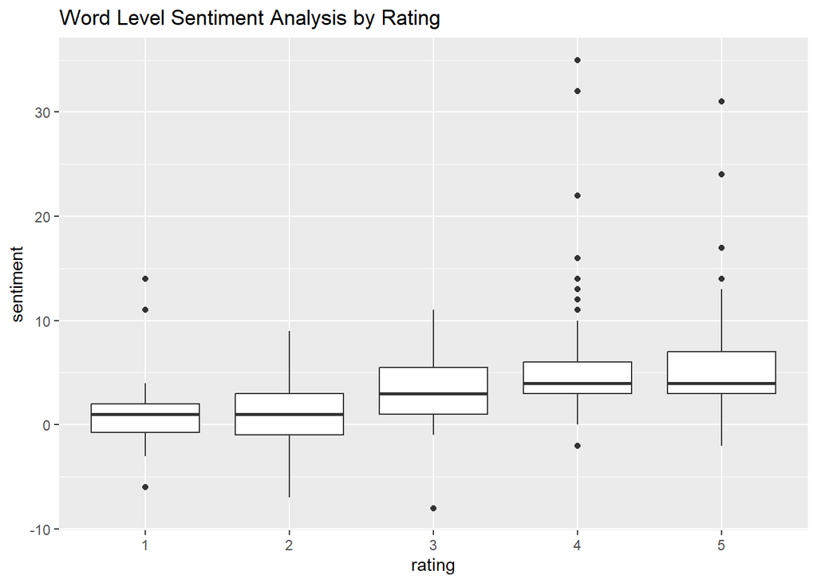

```r
ggplot(token_sentiment, aes(x = rating, y = sentiment))+
  geom_boxplot()+
  ggtitle("Word Level Sentiment Analysis by Rating")
```

### 3. Repeat the same task using the sentence-level sentiment analysis approach. Use the default lexicon

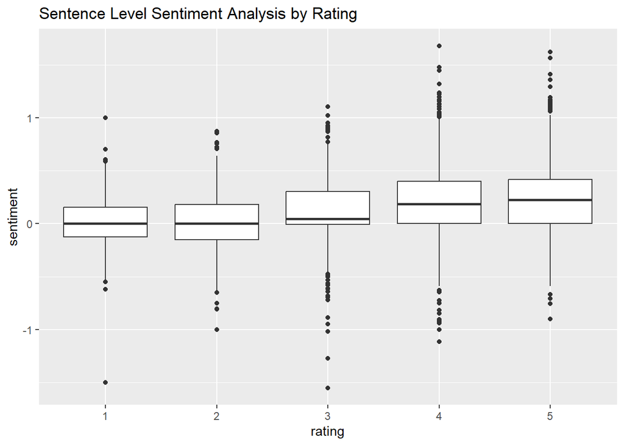

```r
sentence_sentiment <- ecReviews %>%
  get_sentences() %>%
  sentiment()

ggplot(sentence_sentiment, aes(x = rating, y = sentiment))+
  geom_boxplot()+
  ggtitle("Sentence Level Sentiment Analysis by Rating")
```

### 4. Explain how and why the two charts differ.

If you look at the y axis, you will see different values used in each graph. Part of the reason is that there are obviously more variables to set a sentiment to in word-level analysis. the bing lexicon also doesnt recognize every word, and it categorizes into binary sentiment. The sentence level analysis takes valence shifters, or words that have impact to overall polarity, into consideration. Although both graphs are different for the stated reasons, you can see that the trend rating-to-rating is very similar.

# PART II: Labeling Previously Unlabeled News Articles

## You are presented with 31 news articles that were scraped from a popular news site over a one-month period. Unfortunately, the intern who scraped the data failed to capture the appropriate topical labels for each article. The articles are available for download here: https://s3.amazonaws.com/notredame.analytics.data/newsarticles.csv. Your task is to rely on your analytic expertise to assign reasonable labels to these articles.

### 1. Import the data and call it news. To verify that the import worked as expected, preview the data using the head() command.

```r
news <- read.csv('https://s3.amazonaws.com/notredame.analytics.data/newsarticles.csv')
head(news, 1)
```

|  | document | body |
| --- | --- | --- |
| 1 | 1 | 7.34pm GMT England win the series That puts England 2-0 up with two to play. In truth it wasn\x92t the highest quality game \x96 James Vince\x92s 38 was the highest score and the only truly noteworthy… |

### 2. The news dataset is not in the appropriate file encoding and is full of HTML tags. To convert the file encoding from “latin1” to “ASCII” and to remove the HTML tags, run the following piece of code. Preview the data using the head() command to verify that the conversion worked as expected.

```r
library(rvest)
library(xml2)
articles <- vector()
for (row in 1:nrow(news)) {
articles[row] <- news[row, "body"] %>%
iconv(from = "latin1", to = "ASCII", sub = "") %>%
read_html() %>%
html_text()
}
news <- tibble(document = 1:length(articles),
body = articles)

head(news, 1)
```

| document | body |
| --- | --- |
| 1 | 7.34pm GMT England win the series That puts England 2-0 up with two to play. In truth it wasnt the highest quality game James Vinces 38 was the highest score and the only truly noteworthy performances… |

### 3. To further prepare the data for analysis, remove any references to time (such as 7.53 pm GMT), and remove numbers. Preview the data one more time using the head() command to verify that the data is as expected.

```r
#I tokenize the news data first to separate all words in "body"
news_token <- news %>%
  unnest_tokens(output = word, input = body)
news_token
```

| document | word |
| --- | --- |
| 1 | 7.34pm |
| 1 | gmt |
| 1 | england |
| 1 | win |
| 1 | the |
| 1 | series |
| 1 | that |
| 1 | puts |
| 1 | england |
| 1 | 2 |

[output cut: 9990 more lines]

```r
#Here I've created a function using regex and the gsub() function within to replace time formatted as "##.##pm", any instances of "gmt" and any numbers formatted as integers or floats, and then create a dataframe from the word output
remove_time_nums <- function(df) {
  cleaned_df <- lapply(df, function(token) {
    token <- gsub("^\\d{1,2}\\.\\d{2}[ap]m$", "", token)
    token <- gsub("^gmt$", "", token, ignore.case = TRUE)
    token <- gsub("\\d+(\\.\\d+)?", "", token)
  })
  return(data.frame(cleaned_df$word))
}
#Here I apply the function to my tokenized dataframe and cbind with news to set all document numbers back with the correct tokens. I also delete all blank rows.
no_time_nums <- remove_time_nums(news_token)


news_token_clean <- cbind(news_token$document, no_time_nums)

news_token_clean <- news_token_clean %>%
  filter_all(all_vars(!is.na(.) & . != ""))

head(news_token_clean)
```

|  | news_token$document | cleaned_df.word |
| --- | --- | --- |
| 1 | 1 | england |
| 2 | 1 | win |
| 3 | 1 | the |
| 4 | 1 | series |
| 5 | 1 | that |
| 6 | 1 | puts |

### 4. Tokenize, remove stop words, and create a DTM called news_dtm.

I tokenized by word in the previous step, here I will remove the stop words and create the DTM.

```r
news_token <- news_token_clean %>%
  rename(document = `news_token$document`) %>%
  rename(word = cleaned_df.word) %>%
  anti_join(stop_words, by = "word")

news_dtm <- news_token %>%
  count(document, word) %>%
  ungroup() %>%
  cast_dtm(document, word, n)
```

### 5. With alpha set to 0.5, delta set to 0.1, and a seed of 1, train an LDA topic model (based on Gibbs sampling) that assigns each of the articles in news_dtm to one of two topic categories.

```r
news_lda <- news_dtm %>%
  LDA(k = 2, method = "Gibbs", control = list(alpha = 0.5, delta = 0.1, seed = 1))

news_lda
```

```
## A LDA_Gibbs topic model with 2 topics.
```

### 6. List the top 10 terms within each topic and assign a “descriptive label” to each topic.

```r
news_topics <- news_lda %>%
  tidy(matrix = "beta")
news_topics
```

| topic | term | beta |
| --- | --- | --- |
| 1 | aamir | 4.504283e-05 |
| 2 | aamir | 6.864737e-06 |
| 1 | absolutely | 7.002113e-04 |
| 2 | absolutely | 2.814542e-04 |
| 1 | absurd | 1.678869e-04 |
| 2 | absurd | 6.864737e-06 |
| 1 | ad | 1.269389e-04 |
| 2 | ad | 6.864737e-06 |
| 1 | add | 1.269389e-04 |
| 2 | add | 6.864737e-06 |

[output cut: 9990 more lines]

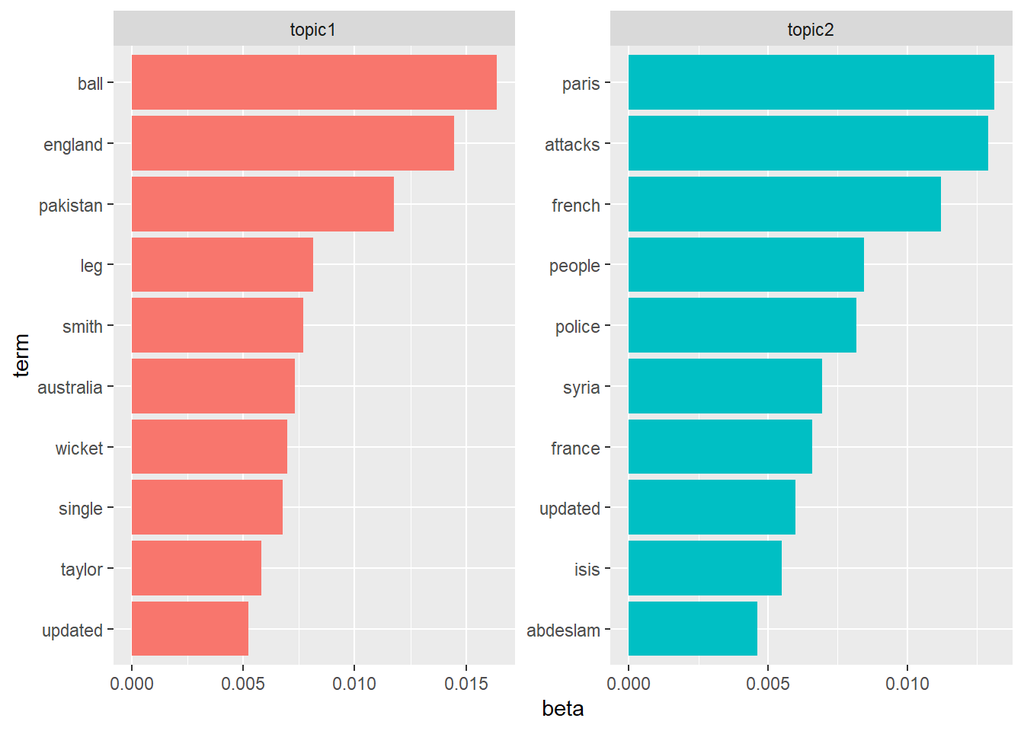

```r
news_topics %>%
  mutate(topic = str_c("topic", topic)) %>%
  group_by(topic) %>%
  top_n(10, beta) %>%
  ungroup() %>%
  arrange(topic, -beta) %>%
  mutate(term = reorder_within(term, beta, topic)) %>%
  ggplot(mapping = aes(x = term, y = beta, fill = factor(topic))) +
  geom_col(show.legend = FALSE) +
  facet_wrap(~ topic, scales = "free") +
  coord_flip() +
  scale_x_reordered()
```

```r
news_documents <- news_lda %>%
  tidy(matrix = "gamma")

news_documents
```

| document | topic | gamma |
| --- | --- | --- |
| 1 | 1 | 0.996225665 |
| 2 | 1 | 0.865196078 |
| 3 | 1 | 0.996631206 |
| 4 | 1 | 0.129310345 |
| 5 | 1 | 0.993778281 |
| 6 | 1 | 0.888692580 |
| 7 | 1 | 0.596916300 |
| 8 | 1 | 0.916909621 |
| 9 | 1 | 0.978537170 |
| 10 | 1 | 0.864820847 |

[output cut: 52 more lines]

```r
news_documents %>%
  mutate(topic = str_c("topic", topic)) %>%
  pivot_wider(names_from = topic, values_from = gamma) %>%
  arrange(desc(abs(topic1 - topic2)))
```

| document | topic1 | topic2 |
| --- | --- | --- |
| 3 | 0.996631206 | 0.003368794 |
| 1 | 0.996225665 | 0.003774335 |
| 5 | 0.993778281 | 0.006221719 |
| 31 | 0.008643547 | 0.991356453 |
| 9 | 0.978537170 | 0.021462830 |
| 30 | 0.970077864 | 0.029922136 |
| 16 | 0.041666667 | 0.958333333 |
| 29 | 0.952639555 | 0.047360445 |
| 24 | 0.052346570 | 0.947653430 |
| 26 | 0.061038961 | 0.938961039 |

[output cut: 21 more lines]

I went back to “news” and read document 3 and document 31 as they are the top of topic1 and topic2 respectively. This helped me understand what each were about.

### 7. For each of the documents in the dataset, list the consensus topic as assigned by the model.

```r
news_by_topic <- news_documents %>%
  mutate(topic = ifelse(topic == 1, "Cricket", "Paris Terrorism")) %>%
  group_by(document) %>%
  top_n(1, gamma) %>%
  ungroup() %>%
  arrange(as.integer(document))

news_by_topic
```

| document | topic | gamma |
| --- | --- | --- |
| 1 | Cricket | 0.9962257 |
| 2 | Cricket | 0.8651961 |
| 3 | Cricket | 0.9966312 |
| 4 | Paris Terrorism | 0.8706897 |
| 5 | Cricket | 0.9937783 |
| 6 | Cricket | 0.8886926 |
| 7 | Cricket | 0.5969163 |
| 8 | Cricket | 0.9169096 |
| 9 | Cricket | 0.9785372 |
| 10 | Cricket | 0.8648208 |

[output cut: 21 more lines]